# Discussion 6

Dmitriy Izyumin

February 12, 2017

# Forecasting Example

### Data

The data for this example is in the file `disc06data.txt`. Read it into R and save it as a numeric vector.

```r
x = read.table('disc06data.txt')
x = x[,1]
```

### Inspect the Data

Let’s take a look at the time series plot, and the sample ACF and PACF plots.

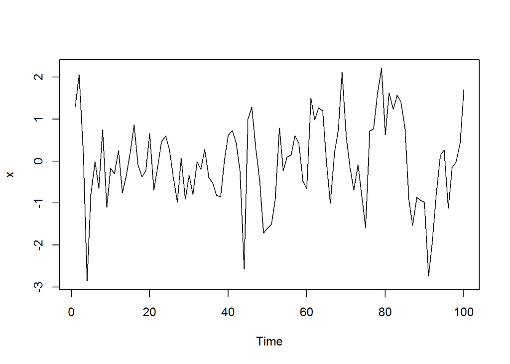

```r
plot.ts(x)
```

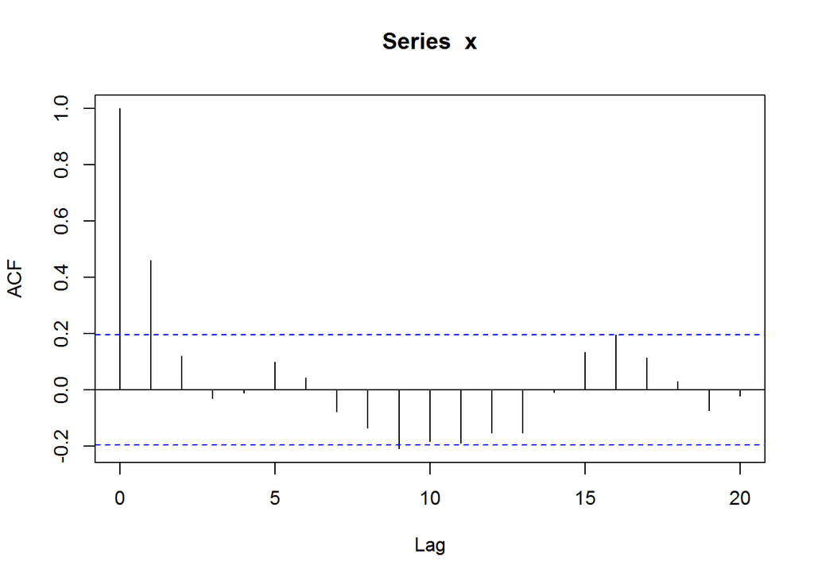

```r
acf(x)
```

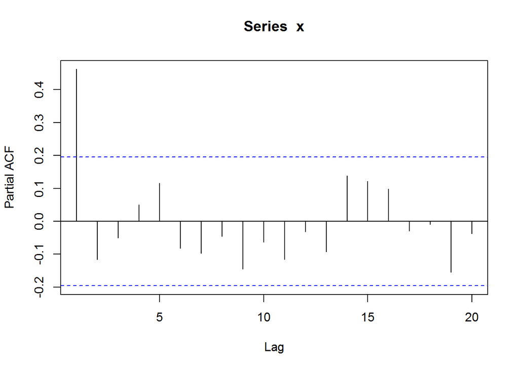

```r
pacf(x)
```

Comments?

Note that by default, the sample ACF values are plotted starting at lag 0, but the sample PACF values are plotted starting at lag 1. This could be confusing, and might even lead to mistakes if the plots are used as a quick way to choose a candidate models.

If presenting the plots, then it is a good idea to clean them up a little. Let’s delete the lag 0 sample ACF value (why don’t we care about it?), and use the same y-axis scale for the two plots. This can be done using the `xlim` and `ylim` arguments, and the actual values depend on the data.

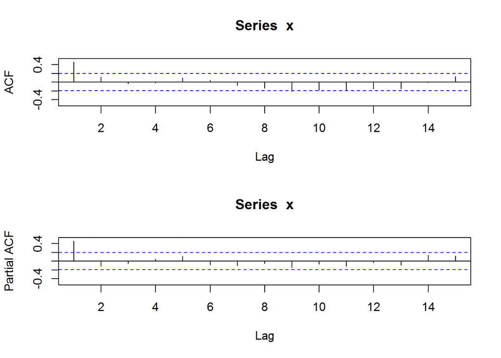

```r
par(mfrow = c(2,1))
acf(x, xlim = c(1,15), ylim = c(-0.5, 0.5))
pacf(x, xlim = c(1,15), ylim = c(-0.5, 0.5))
```

```r
par(mfrow = c(1,1))
```